# EXPLORING PROSPER LOAN DATASET

## 6.2 Bivariate Exploration

> In this section, we will investigate relationships between pairs of variables in our dataframe. The variables that are covered here have been introduced in the previous section (univariate exploration) above.
> - We will begin by exploring correlations between our numerical variables, as it will provide a lucid insight into our target variables which are Borrower APR and Prosper rating.

```python
#A look at our dataframe
clean_df
```

|  | Term | LoanStatus | ListingCreationDate | ListingCategory | EmploymentStatus | EmploymentStatusDuration | IncomeRange | IncomeVerifiable | IsBorrowerHomeowner | DebtToIncomeRatio | StatedMonthlyIncome | LoanOriginalAmount | ProsperScore | ProsperRating | BorrowerAPR |
| --- | --- | --- | --- | --- | --- | --- | --- | --- | --- | --- | --- | --- | --- | --- | --- |
| 3 | 36 | Current | 2023-02-12 02:35:00 | Motorcycle | Employed | 113.0 | $25,000-49,999 | True | True | 0.15 | 2875.000000 | 10000 | 9.0 | A | 0.12528 |
| 10 | 60 | Current | 2023-02-12 04:01:36 | Debt Consolidation | Employed | 300.0 | $75,000-99,999 | True | False | 0.12 | 7500.000000 | 13500 | 7.0 | C | 0.27462 |
| 12 | 36 | Past Due (1-15 days) | 2023-02-12 01:10:48 | Debt Consolidation | Employed | 1.0 | $25,000-49,999 | True | False | 0.18 | 2416.666667 | 4000 | 4.0 | B | 0.17969 |
| 14 | 60 | Current | 2023-02-12 17:41:42 | Debt Consolidation | Employed | 35.0 | $100,000+ | True | False | 0.20 | 10833.333330 | 19330 | 8.0 | A | 0.11695 |
| 15 | 36 | Defaulted | 2023-02-12 14:46:18 | Household Expenses | Other | 121.0 | $50,000-74,999 | True | True | 0.49 | 5500.000000 | 4000 | 5.0 | HR | 0.35797 |
| ... | ... | ... | ... | ... | ... | ... | ... | ... | ... | ... | ... | ... | ... | ... | ... |
| 113916 | 36 | Current | 2023-02-12 07:36:36 | Household Expenses | Employed | 149.0 | $50,000-74,999 | True | False | 0.15 | 4583.333333 | 4000 | 6.0 | E | 0.33286 |
| 113924 | 60 | Current | 2023-02-12 15:52:42 | Household Expenses | Employed | 56.0 | $25,000-49,999 | True | False | 0.17 | 3208.333333 | 5000 | 8.0 | A | 0.17317 |
| 113928 | 36 | Completed | 2023-02-12 02:44:24 | Business | Full-time | 22.0 | $25,000-49,999 | True | False | 0.27 | 2333.333333 | 2000 | 6.0 | C | 0.22362 |
| 113931 | 60 | Current | 2023-02-12 13:08:00 | Business | Employed | 12.0 | $75,000-99,999 | True | False | 0.28 | 8146.666667 | 25000 | 6.0 | B | 0.15016 |
| 113935 | 60 | Completed | 2023-02-12 18:26:36 | Home Improvement | Full-time | 94.0 | $25,000-49,999 | True | True | 0.48 | 3875.000000 | 15000 | 5.0 | C | 0.28408 |

31037 rows × 15 columns

### Question A. What is the relationship you observed amongst the numeric variables [ DebtToIncomeRatio, StatedMonthlyIncome, LoanOriginalAmount, BorrowerAPR and Term]. Do they show any correlation?

### `Visualization`

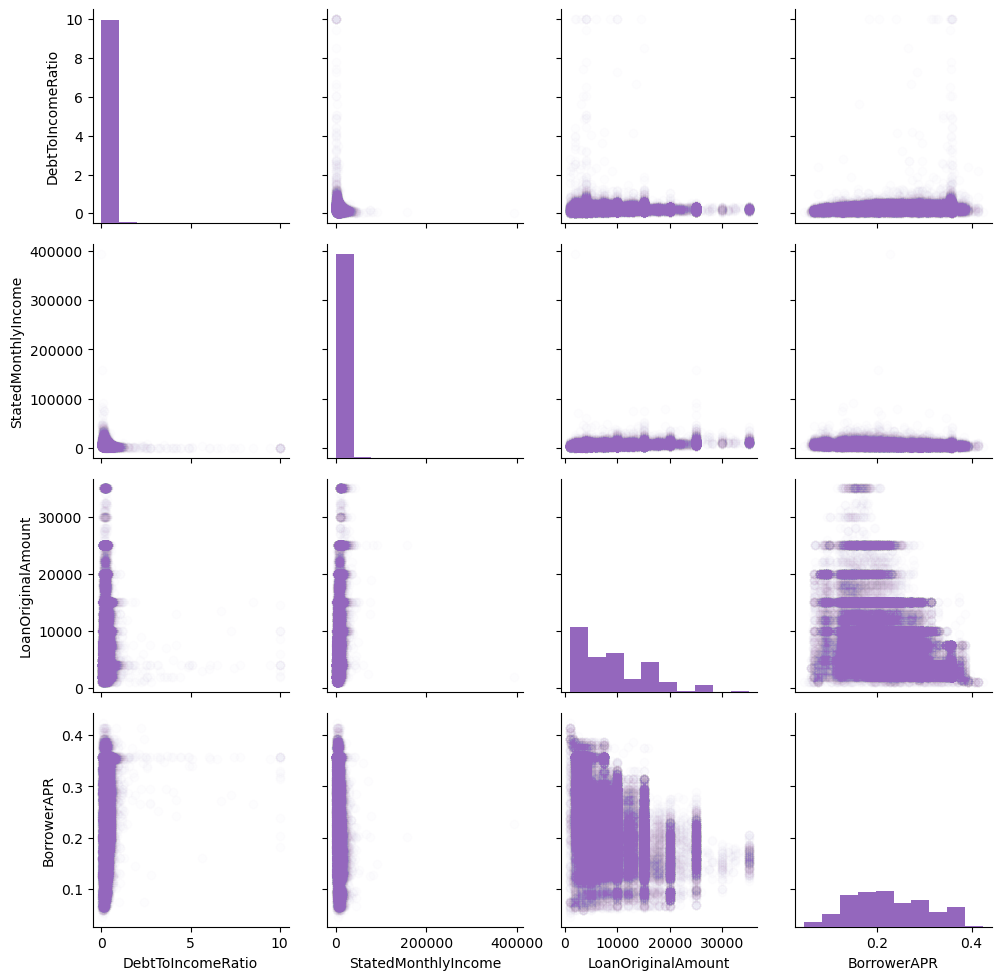

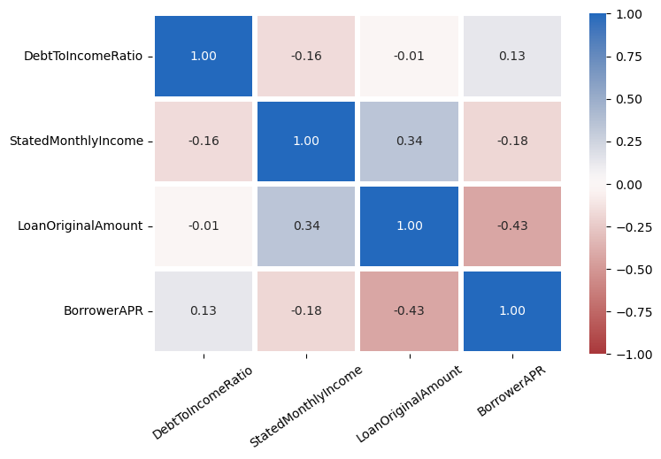

```python
#we will use the seaborn PairGrid and Heatmat

# creating a list of numeric variables
numeric_vars = ['DebtToIncomeRatio', 'StatedMonthlyIncome', 'LoanOriginalAmount', 'BorrowerAPR', 'Term']

# Creating a scatterplot of each numeric variable against the other
fig = sns.PairGrid(clean_df[numeric_vars])
fig.map_diag(plt.hist, color = colors[4])
fig.map_offdiag(plt.scatter,color = colors[4], alpha=0.01);

# Visualizing the correlation between the numeric variables with a heatmap
plt.figure(figsize= (7.5, 5))
sns.heatmap(data=clean_df[numeric_vars].corr(), annot=True, fmt='.2f',
            cmap='vlag_r', vmin=-1, vmax=1, linewidth=3)
plt.xticks(rotation=35);
```

### Question B. Can you visualize the relationship between BorrowerAPR and LoanOriginalAmount only.

### `Visualization`

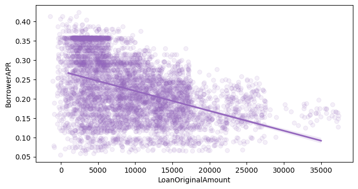

```python
# using regplot and a sample of 5000 to avoid overplotting

plt.figure(figsize=(8, 4))
sns.regplot(data=clean_df.sample(5000, random_state=1), x='LoanOriginalAmount', y='BorrowerAPR',
            x_jitter=2500, color = colors[4], scatter_kws={'alpha': 0.1});
```